# Cars dataset

Sergio Giraldo

July, 2019

## Analysis

The data used for the analysis is the `mtcars` data set, a dataset builtin in R. The data was extracted from the 1974 Motor Trend US magazine, and comprises fuel consumption and 10 aspects of automobile design and performance for 32 automobiles (1973 and 1974 models).

### Loading the data

```r
data(mtcars)
mtcars
```

```
##                      mpg cyl  disp  hp drat    wt  qsec vs am gear carb
## Mazda RX4           21.0   6 160.0 110 3.90 2.620 16.46  0  1    4    4
## Mazda RX4 Wag       21.0   6 160.0 110 3.90 2.875 17.02  0  1    4    4
## Datsun 710          22.8   4 108.0  93 3.85 2.320 18.61  1  1    4    1
## Hornet 4 Drive      21.4   6 258.0 110 3.08 3.215 19.44  1  0    3    1
## Hornet Sportabout   18.7   8 360.0 175 3.15 3.440 17.02  0  0    3    2
## Valiant             18.1   6 225.0 105 2.76 3.460 20.22  1  0    3    1
## Duster 360          14.3   8 360.0 245 3.21 3.570 15.84  0  0    3    4
## Merc 240D           24.4   4 146.7  62 3.69 3.190 20.00  1  0    4    2
## Merc 230            22.8   4 140.8  95 3.92 3.150 22.90  1  0    4    2
## Merc 280            19.2   6 167.6 123 3.92 3.440 18.30  1  0    4    4
## Merc 280C           17.8   6 167.6 123 3.92 3.440 18.90  1  0    4    4
## Merc 450SE          16.4   8 275.8 180 3.07 4.070 17.40  0  0    3    3
## Merc 450SL          17.3   8 275.8 180 3.07 3.730 17.60  0  0    3    3
## Merc 450SLC         15.2   8 275.8 180 3.07 3.780 18.00  0  0    3    3
## Cadillac Fleetwood  10.4   8 472.0 205 2.93 5.250 17.98  0  0    3    4
## Lincoln Continental 10.4   8 460.0 215 3.00 5.424 17.82  0  0    3    4
## Chrysler Imperial   14.7   8 440.0 230 3.23 5.345 17.42  0  0    3    4
## Fiat 128            32.4   4  78.7  66 4.08 2.200 19.47  1  1    4    1
## Honda Civic         30.4   4  75.7  52 4.93 1.615 18.52  1  1    4    2
## Toyota Corolla      33.9   4  71.1  65 4.22 1.835 19.90  1  1    4    1
## Toyota Corona       21.5   4 120.1  97 3.70 2.465 20.01  1  0    3    1
## Dodge Challenger    15.5   8 318.0 150 2.76 3.520 16.87  0  0    3    2
## AMC Javelin         15.2   8 304.0 150 3.15 3.435 17.30  0  0    3    2
## Camaro Z28          13.3   8 350.0 245 3.73 3.840 15.41  0  0    3    4
## Pontiac Firebird    19.2   8 400.0 175 3.08 3.845 17.05  0  0    3    2
## Fiat X1-9           27.3   4  79.0  66 4.08 1.935 18.90  1  1    4    1
## Porsche 914-2       26.0   4 120.3  91 4.43 2.140 16.70  0  1    5    2
## Lotus Europa        30.4   4  95.1 113 3.77 1.513 16.90  1  1    5    2
## Ford Pantera L      15.8   8 351.0 264 4.22 3.170 14.50  0  1    5    4
## Ferrari Dino        19.7   6 145.0 175 3.62 2.770 15.50  0  1    5    6
## Maserati Bora       15.0   8 301.0 335 3.54 3.570 14.60  0  1    5    8
## Volvo 142E          21.4   4 121.0 109 4.11 2.780 18.60  1  1    4    2
```

```r
mtcarsOriginal <- mtcars
```

### Exploring the data

Let’s explore data size

```r
dim(mtcars)
```

```
## [1] 32 11
```

Structure of the data:

```r
str(mtcars)
```

```
## 'data.frame':    32 obs. of  11 variables:
##  $ mpg : num  21 21 22.8 21.4 18.7 18.1 14.3 24.4 22.8 19.2 ...
##  $ cyl : num  6 6 4 6 8 6 8 4 4 6 ...
##  $ disp: num  160 160 108 258 360 ...
##  $ hp  : num  110 110 93 110 175 105 245 62 95 123 ...
##  $ drat: num  3.9 3.9 3.85 3.08 3.15 2.76 3.21 3.69 3.92 3.92 ...
##  $ wt  : num  2.62 2.88 2.32 3.21 3.44 ...
##  $ qsec: num  16.5 17 18.6 19.4 17 ...
##  $ vs  : num  0 0 1 1 0 1 0 1 1 1 ...
##  $ am  : num  1 1 1 0 0 0 0 0 0 0 ...
##  $ gear: num  4 4 4 3 3 3 3 4 4 4 ...
##  $ carb: num  4 4 1 1 2 1 4 2 2 4 ...
```

This is the purpose for each feature:

- **mpg:** Miles/(US) gallon
- **cyl:** Number of cylinders
- **disp:** Displacement (cu.in.)
- **hp:** Gross horsepower
- **drat:** Rear axle ratio
- **wt:** Weight (1000 lbs)
- **qsec:** 1/4 mile time
- **vs:** V/S
- **am:** Transmission (0 = automatic, 1 = manual)
- **gear:** Number of forward gears
- **carb:** Number of carburetors

Of particular interest is `mpg` (Miles/US gallon) variable as result variable.

### Data transformation

For interpretability, let’s transform some of the variables

```r
mtcars$cyl <- factor(mtcars$cyl)
mtcars$vs <- factor(mtcars$vs)
mtcars$gear <- factor(mtcars$gear)
mtcars$carb <- factor(mtcars$carb)
```

Also, let’s convert predictor variable `am` to factor levels `Automatic` and `Manual`.

```r
mtcars$am <- factor(mtcars$am, labels = c("Automatic", "Manual"))
```

Figure below shows how miles per US Gallon (`mpg`) relates to transmission type and gives a hint manual transmission is better.

```r
library(ggplot2)
```

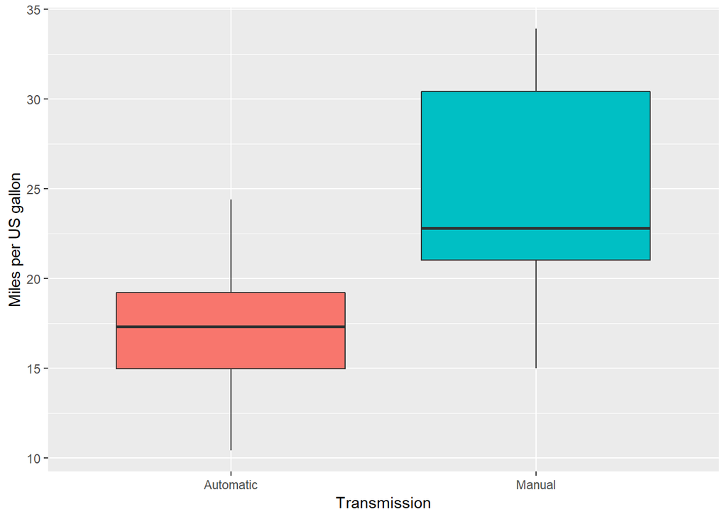

```r
ggplot(mtcars, aes(x=am, y=mpg, fill=am)) +
  geom_boxplot() +
  ylab("Miles per US gallon") +
  xlab("Transmission") +
  guides(fill=FALSE)
```

This can be confirmed comparing averages of Miles per Gallon by transmission type

```r
aggregate(mpg ~ am, data = mtcars, mean)
```

```
##          am      mpg
## 1 Automatic 17.14737
## 2    Manual 24.39231
```

Notice the difference between them. It seems manual transmissions gets better gas mileage and needs to investigate if this impact is due only to transmission type or a mix of other car characteristics.

### Model selection

Let’s compare a simple linear model based only on `mpg` and `am` variables. Then let’s use an automatic model selection based on the R `step` function.

Let’s start by looking at the variables correlation to the outcome `mpg`.

#### Correlation

To determine which predictor variables should be included in the regression model, let’s build a correlation matrix and check how each of the variable is related to the `mpg` variable.

```r
# using the original mtcars without transformations
sort(cor(mtcarsOriginal)[1,])
```

```
##         wt        cyl       disp         hp       carb       qsec
## -0.8676594 -0.8521620 -0.8475514 -0.7761684 -0.5509251  0.4186840
##       gear         am         vs       drat        mpg
##  0.4802848  0.5998324  0.6640389  0.6811719  1.0000000
```

The result shows that the most correlated variables to `mpg` (except `am` that needs to be included in the model) are `wt`, `cyl`, `disp` and `hp`. However it seems that `cyl` and `disp` are collinear and only `cyl` will be included in the model.

The model will use as predictors the following variables:

- `am`;
- `wt`;
- `cyl`;
- `hp`.

Except for the `am` variable, all the others have negative impact on the `mpg`, which is quite logical because the more important the car weight is, or the horse power, the fewer miles per gallon it can make. This will be confirmed later in the automatic model selection.

#### Linear regression models

Let’s start the model testing with a simple model and single predictor variable `am`.

```r
fit1 <- lm(mpg ~ am, data = mtcars)
summary(fit1)
```

```
##
## Call:
## lm(formula = mpg ~ am, data = mtcars)
##
## Residuals:
##     Min      1Q  Median      3Q     Max
## -9.3923 -3.0923 -0.2974  3.2439  9.5077
##
## Coefficients:
##             Estimate Std. Error t value Pr(>|t|)
## (Intercept)   17.147      1.125  15.247 1.13e-15 ***
## amManual       7.245      1.764   4.106 0.000285 ***
## ---
## Signif. codes:  0 '***' 0.001 '**' 0.01 '*' 0.05 '.' 0.1 ' ' 1
##
## Residual standard error: 4.902 on 30 degrees of freedom
## Multiple R-squared:  0.3598, Adjusted R-squared:  0.3385
## F-statistic: 16.86 on 1 and 30 DF,  p-value: 0.000285
```

Interpreting the result, notice cars with manual transmission have **7.245** Miles per Gallon more than the automatic. However, R-squared value is **0.3598**, which means that only **35.98%** of the variance is explained by the model.

Let’s understand the impact of the other variables in the result feature.

Let’s try with automatic model selection

```r
fit2 <- step(lm(mpg ~ ., data = mtcars), trace=0, steps=1000, direction="both")
summary(fit2)
```

```
##
## Call:
## lm(formula = mpg ~ cyl + hp + wt + am, data = mtcars)
##
## Residuals:
##     Min      1Q  Median      3Q     Max
## -3.9387 -1.2560 -0.4013  1.1253  5.0513
##
## Coefficients:
##             Estimate Std. Error t value Pr(>|t|)
## (Intercept) 33.70832    2.60489  12.940 7.73e-13 ***
## cyl6        -3.03134    1.40728  -2.154  0.04068 *
## cyl8        -2.16368    2.28425  -0.947  0.35225
## hp          -0.03211    0.01369  -2.345  0.02693 *
## wt          -2.49683    0.88559  -2.819  0.00908 **
## amManual     1.80921    1.39630   1.296  0.20646
## ---
## Signif. codes:  0 '***' 0.001 '**' 0.01 '*' 0.05 '.' 0.1 ' ' 1
##
## Residual standard error: 2.41 on 26 degrees of freedom
## Multiple R-squared:  0.8659, Adjusted R-squared:  0.8401
## F-statistic: 33.57 on 5 and 26 DF,  p-value: 1.506e-10
```

Notice the automatic model selection is based on the same variables that were chosen based on the correlation check, i.e., `am`, `wt`, `cyl` and `hp`.

This shows that the most negative influence on the Miles per gallon are cylinders (`cyl`) and weight (`wt`). For example, each increase in weight by 1000 lb (`wt`) decreases the `mpg` by **2.49683** miles. It is also quite expected that as more cylinders a car have, the more gas it will use. The same goes for horse power (`hp`).

As for R-squared, value is **0.8659** which means that **86.59%** of the variation is explained by the model which indicates it’s a robust and highly predictive model.

Comparing the model `fit1` to `fit2` using ANOVA, it shows the second model `fit2`, based on multi-variable regression, is superior to the first model.

```r
anova(fit1, fit2)
```

```
## Analysis of Variance Table
##
## Model 1: mpg ~ am
## Model 2: mpg ~ cyl + hp + wt + am
##   Res.Df    RSS Df Sum of Sq      F    Pr(>F)
## 1     30 720.90
## 2     26 151.03  4    569.87 24.527 1.688e-08 ***
## ---
## Signif. codes:  0 '***' 0.001 '**' 0.01 '*' 0.05 '.' 0.1 ' ' 1
```

The p-value of **1.688e-08** endorses that conclusion.

### Diagnostics

Once the model is selected (`fit2`), the next thing to do would be to run some diagnostics and to look at the **Residuals** plot (refer to **Figure 1** in appendix).

The normal Q-Q plot shows residual points located mostly near the line implying the residuals are normally distributed. The Residuals vs. Fitted plot show randomly scattered points above and below the 0 line. We cannot see any pattern which means it show normality and no evidence of heteroscedasticity.

## Conclusion

This analysis allowed to answer which type of transmission has a better MPG (Miles per gallon) average. The cars with manual transmissions tend to have a better gas millage on average. The best model `fit2` explained **86%** of the variance but there is still some amount of uncertainty.

## Appendix

### Figure 1: Diagnostic plots

The normal Q-Q plot shows residual points located mostly near the line implying the residuals are normally distributed. The Residuals vs. Fitted plot show randomly scattered points above and below the 0 line. We cannot see any pattern which means it show normality and no evidence of heteroscedasticity.

```r
library(ggfortify)
```

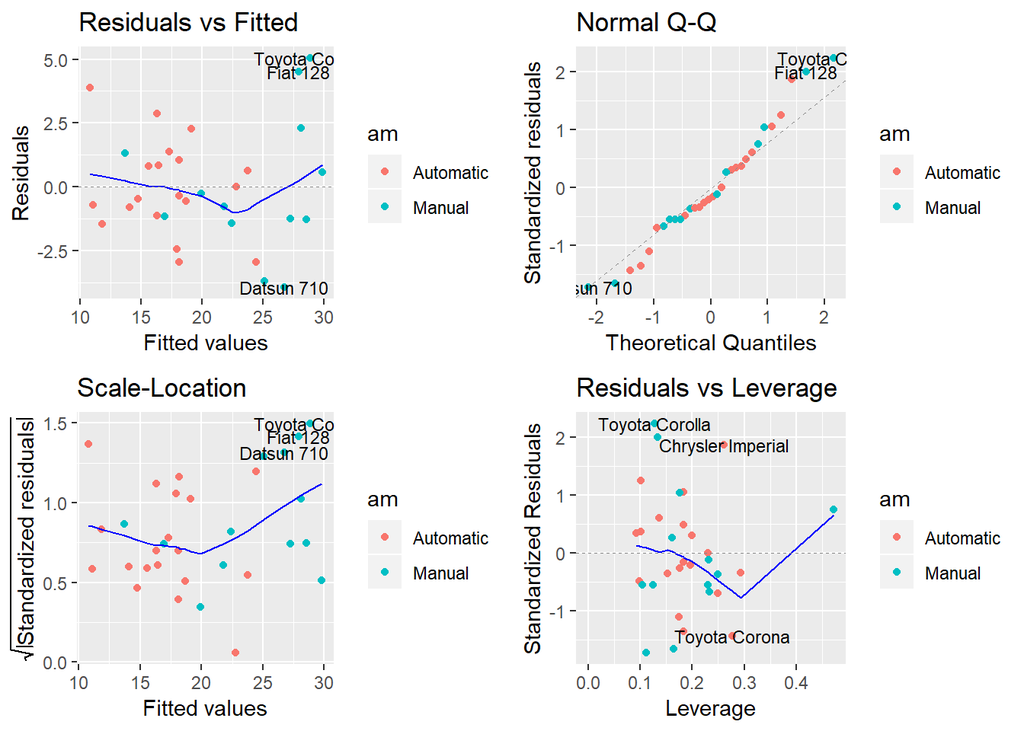

```r
autoplot(fit2, data = mtcars,
         colour = 'am', label.size = 3)
```

### Figure 2: Weight per transmission type

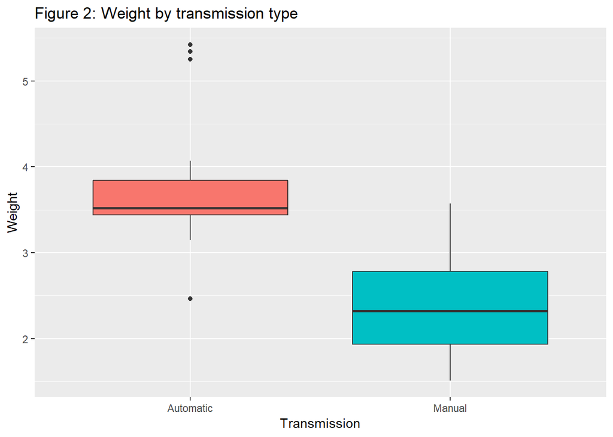

```r
ggplot(mtcars, aes(x=am, y=wt, fill=am)) +
  geom_boxplot() +
  ylab("Weight") +
  xlab("Transmission") +
  ggtitle("Figure 2: Weight by transmission type") +
  guides(fill=FALSE)
```